# Tagu et al. (2022): the fitted model

In Tagu et al. (2022, *Cognition*), people used a mouse to forage for targets of three colours among distractors (54 items per trial) in two conditions: a **value** condition, where one target colour was worth more than the others, and a **control** condition without values. The question is how value, proximity and priming (the type just selected) shape which target is selected next.

Here the three target colours are the item classes of a categorical (`cat`) model. In each block, class 1 is the block’s designated colour (the high-value colour in the value condition, a nominal category in the control) and classes 2 and 3 are the other two colours, in colour-number order, which is arbitrary: so only class 1 is comparable across people and conditions.

*Note*: this is the only dataset here with more than two item classes, so the only one that can test whether the full class-transition matrix (`b_v`) is needed. With two classes the matrix is the same model as the papers’ class weight and stick/switch rate (`b_a`, `b_s`; see the simulated cat example); with three it has six free probabilities against their three (two class weights, one stick/switch rate). An earlier comparison (`analysis/stick_switch/`, Oct 3 2026: single-level fits per person, older code) found the matrix ahead by 159 +- 50 elpd, mostly in the value condition (125 +- 45; control 34 +- 21): how sticky people are depends on the colour, which one stick/switch rate can’t capture.

This page reads the multi-level Fourier-124 fit made by `../fit_models/fit_models.R` (nothing is refitted here; to fit the model yourself, `fit_tagu2022cog.R` is the minimal pipeline) and shows how to work with a fitted model: checking convergence, reading the posterior, accuracy and posterior predictive checks. It ends with a model comparison, three item classes against two. The fit’s settings are the defaults: the default priors, centred distance and class effects, 4 chains of 1000 warmup and 1000 sampling iterations.

Code: `tagu2022cog.R`.

```r
source("../../../functions/set_up_FoMo.R")
```

```
[1] "set_up_FoMo.R: random seed set to 65 (FOMO_SEED)"
```

```r
source("../fit_models/fit_settings.R")

# the fits this page reads (made by ../fit_models/fit_models.R)
require_example_fits(c("tagu2022cog_fourier124", "tagu2022cog2items_fourier124"))

n_post_draws <- 20   # posterior draws for the posterior predictive check
```

## 1 The data

```r
d <- import_data("tagu2022cog")

d$stim |>
  summarise(people = n_distinct(person), trials = n_distinct(trial),
            items_per_trial = n() / n_distinct(trial), .by = condition) |>
  left_join(summarise(d$found, selections = n(), .by = condition), by = "condition") |>
  knitr::kable()
```

| condition | people | trials | items_per_trial | selections |
| --- | --- | --- | --- | --- |
| value | 24 | 210 | 54 | 9771 |
| control | 24 | 239 | 54 | 12906 |

One random trial from each condition. Items are coloured by target type (the three colours); the line is the order the targets were selected in.

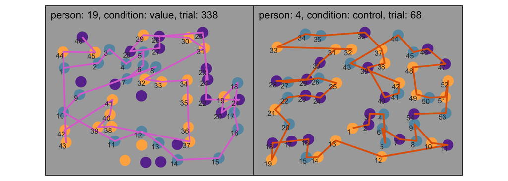

Figure 1: One trial per condition: items and selection order.

```r
plot_trial(d$found, d$stim)
```

How long people kept selecting the same target type before switching (runs).

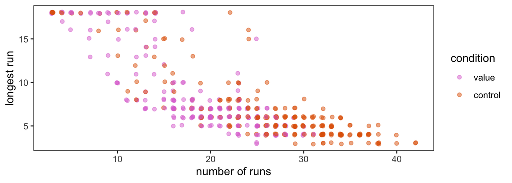

Figure 2: Run lengths by condition.

```r
plot_runs(compute_runs(d$found))
```

Per-trial statistics, used below to check the fitted model against the data.

```r
trial_stats <- compute_trial_stats(d$found)
head(trial_stats) |> knitr::kable(digits = 2)
```

| person | condition | n_found | best_r | mean_itd | pao | n_runs | max_run_length |
| --- | --- | --- | --- | --- | --- | --- | --- |
| 1 | value | 46.6 | 0.46 | 0.16 | 32.2 | 25.4 | 5.12 |
| 1 | control | 54.0 | 0.70 | 0.15 | 26.1 | 27.0 | 6.10 |
| 2 | value | 46.2 | 0.60 | 0.15 | 26.5 | 20.7 | 8.11 |
| 2 | control | 54.0 | 0.70 | 0.16 | 38.8 | 19.3 | 8.90 |
| 3 | value | 46.4 | 0.33 | 0.20 | 73.1 | 11.6 | 12.75 |
| 3 | control | 54.0 | 0.53 | 0.20 | 74.2 | 13.2 | 12.80 |

## 2 The fit

```r
# the fit, and the data list it was made from (fit_fomo() stores it;
# read_example_fit() rebuilds it for older fits, like this one, Oct 5 2026)
fit <- read_example_fit(d, "tagu2022cog", "fourier124")
sl <- attr(fit, "fomo_sl")
```

```r
fomo_summary(fit, cond_labels = levels(d$stim$condition))
```

**Fixed effects (median and 97% HPDI)**

| parameter | condition | component | lower | median | upper | rhat | ess_bulk | ess_tail |
| --- | --- | --- | --- | --- | --- | --- | --- | --- |
| rho_delta | value |  | 1.63 | 1.80 | 1.97 | 1.00 | 4660 | 2898 |
| rho_delta | control |  | 1.94 | 2.17 | 2.42 | 1.00 | 5502 | 2556 |
| rho_psi | value |  | -0.90 | -0.66 | -0.45 | 1.00 | 1632 | 2115 |
| rho_psi | control |  | -1.43 | -1.02 | -0.64 | 1.00 | 674 | 1395 |
| fourier_coef | value | h1 cos | -0.08 | -0.01 | 0.06 | 1.00 | 2384 | 2748 |
| fourier_coef | control | h1 cos | -0.50 | -0.22 | 0.09 | 1.01 | 424 | 831 |
| fourier_coef | value | h1 sin | -0.02 | 0.07 | 0.15 | 1.00 | 2167 | 2761 |
| fourier_coef | control | h1 sin | -0.02 | 0.08 | 0.17 | 1.00 | 1419 | 2077 |
| fourier_coef | value | h2 cos | 0.11 | 0.16 | 0.21 | 1.00 | 3887 | 2831 |
| fourier_coef | control | h2 cos | -0.02 | 0.11 | 0.23 | 1.01 | 680 | 1072 |
| fourier_coef | value | h2 sin | -0.01 | 0.05 | 0.10 | 1.00 | 4010 | 2958 |
| fourier_coef | control | h2 sin | 0.01 | 0.08 | 0.15 | 1.00 | 2286 | 2599 |
| fourier_coef | value | h4 cos | 0.22 | 0.27 | 0.31 | 1.00 | 5180 | 3149 |
| fourier_coef | control | h4 cos | 0.21 | 0.28 | 0.35 | 1.00 | 1460 | 2141 |
| fourier_coef | value | h4 sin | -0.02 | 0.04 | 0.10 | 1.00 | 3701 | 2756 |
| fourier_coef | control | h4 sin | -0.08 | -0.02 | 0.03 | 1.00 | 4395 | 2932 |
| b_v | value | 1,1 | 2.39 | 3.37 | 4.34 | 1.00 | 5727 | 2419 |
| b_v | control | 1,1 | 1.20 | 1.61 | 2.06 | 1.00 | 4709 | 2350 |
| b_v | value | 2,1 | 0.29 | 0.77 | 1.20 | 1.00 | 3792 | 2807 |
| b_v | control | 2,1 | -0.14 | 0.20 | 0.54 | 1.00 | 4267 | 2800 |
| b_v | value | 3,1 | -0.60 | -0.20 | 0.25 | 1.00 | 3916 | 3168 |
| b_v | control | 3,1 | -1.97 | -1.60 | -1.19 | 1.00 | 5243 | 2720 |
| b_v | value | 1,2 | -0.42 | -0.15 | 0.12 | 1.00 | 2738 | 2748 |
| b_v | control | 1,2 | -0.13 | 0.13 | 0.39 | 1.00 | 3738 | 2711 |
| b_v | value | 2,2 | 0.87 | 1.11 | 1.38 | 1.00 | 3778 | 2861 |
| b_v | control | 2,2 | 0.97 | 1.47 | 1.94 | 1.00 | 4961 | 2776 |
| b_v | value | 3,2 | -1.74 | -1.36 | -1.02 | 1.00 | 5044 | 2963 |
| b_v | control | 3,2 | -1.90 | -1.46 | -0.98 | 1.00 | 5698 | 2857 |

Convergence (all parameters): largest R-hat 1.009 (fourier_coef[2,3]); smallest bulk ESS 424 (fourier_coef[2,1]), tail ESS 831 (fourier_coef[2,1]); 0 divergent transitions.

Rank plots of the five worst-mixing parameters. If the chains have mixed well, each chain’s histogram is roughly flat and they overlap.

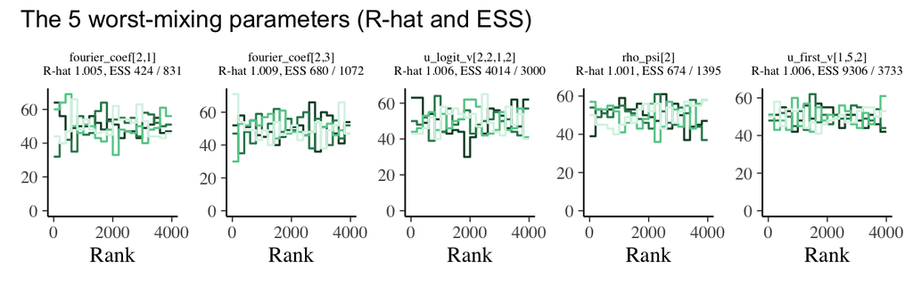

Figure 3: Rank plots of the five worst-mixing parameters, coloured by their R-hat and ESS.

```r
plot_post_traces(fit)
```

## 3 Posterior

`extract_post()` turns the fit’s draws into tidy tables (one per group of parameters), which the `plot_post_*()` functions take.

```r
post <- extract_post(fit, d$found, d$stim)
```

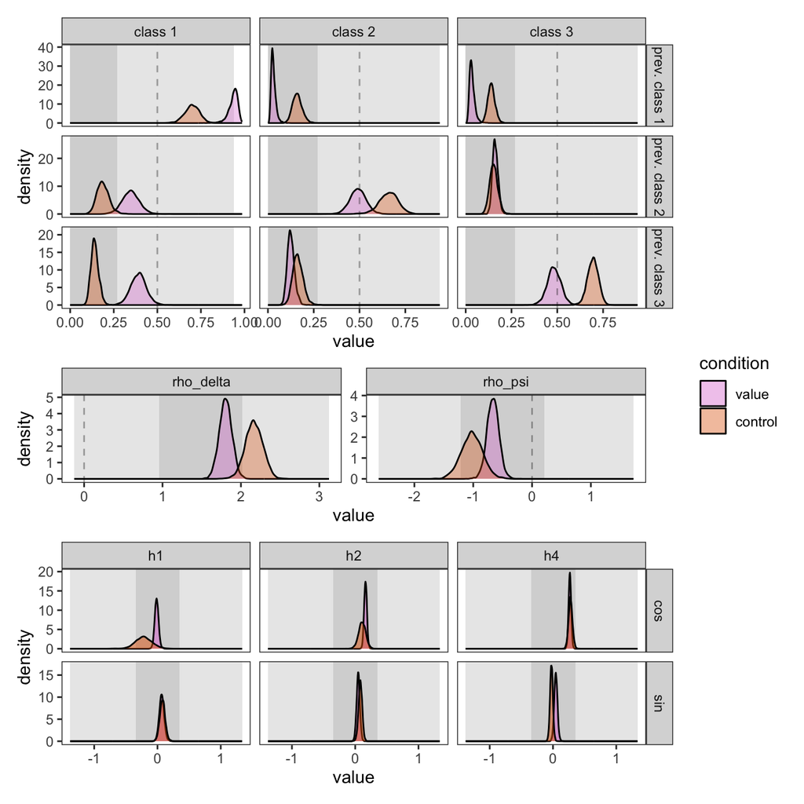

Figure 4: Posterior densities by condition: class transitions, distance and relative direction, and the Fourier coefficients. Grey bands: the priors’ HPDIs.

```r
plot_post(post)
```

The same spatial parameters, shown as what each does to an item’s selection weight:

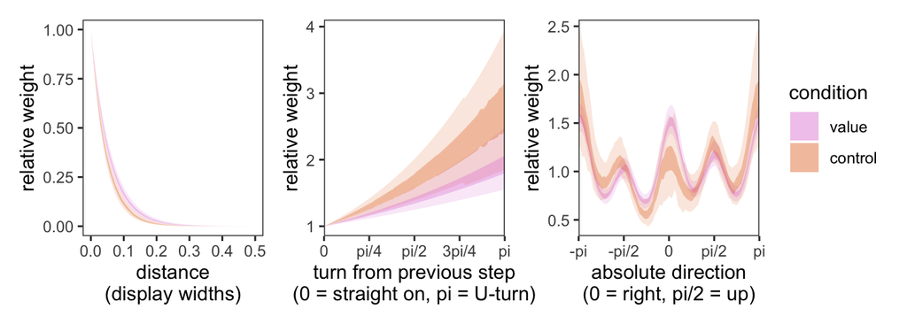

Figure 5: Relative selection weight against distance, turn and absolute direction: 53% and 97% HPDIs.

```r
plot_post_spatial(post, show = "weights")
```

Each person’s distance and relative-direction estimates, over the population’s:

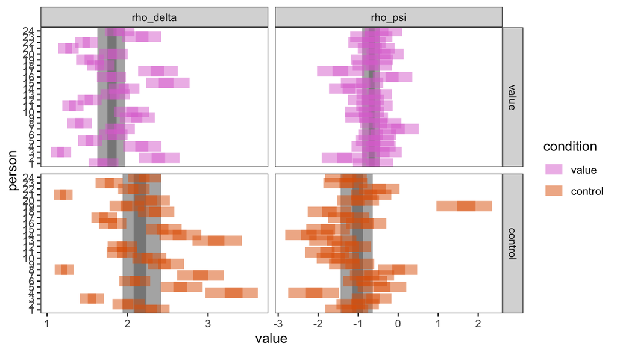

Figure 6: Per-person estimates (intervals) over the population-level HPDIs (grey bands).

```r
plot_post_per_person_spatial(post)
```

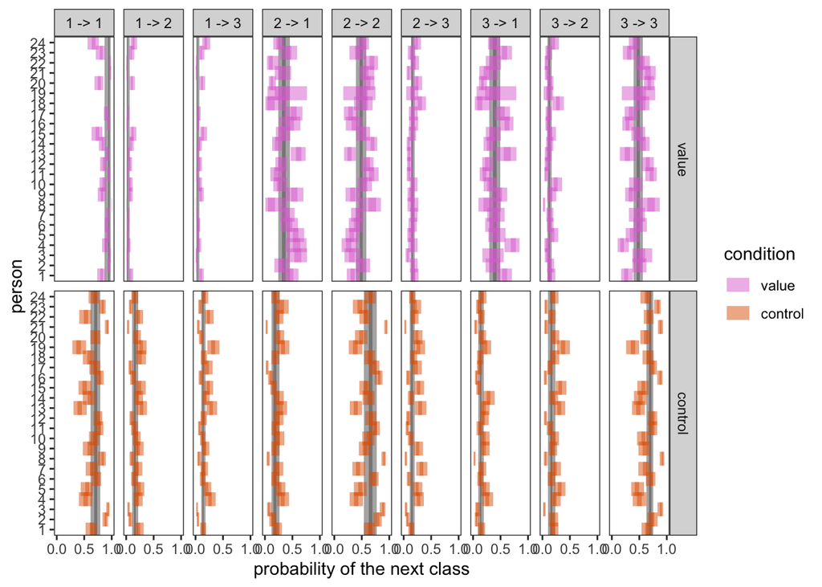

Figure 7: Per-person class-transition probabilities (previous type -> next type) over the population-level HPDIs (grey bands).

```r
plot_post_per_person_cat(post)
```

## 4 Accuracy

The fit doesn’t store a prediction for every selection (`save_selections = FALSE`, the default), so `predict_fomo()` makes them from 200 posterior draws. Deterministic accuracy is how often the item the model judges most likely is the one selected; the probability of the chosen item credits being nearly right too. Chance (dotted) is 1 / items left; the nearest-neighbour rule (dashed) always picks the closest item, so the gap above it is what the model adds to proximity alone. This is in-sample accuracy, which overestimates out-of-sample accuracy.

```r
# the fit doesn't store per-selection predictions (save_selections =
# FALSE), so predict them for a subset of draws
pred <- predict_fomo(fit, sl, n_draws = 200)
acc <- extract_post(pred, d$found, d$stim)$acc
```

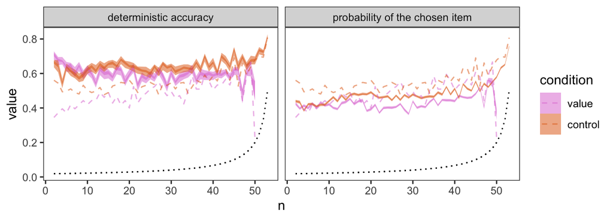

Figure 8: Accuracy at each selection, with chance and nearest-neighbour baselines.

```r
plot_post_accuracy(acc, d$stim, d$found)
```

## 5 Posterior predictive check

Whole trials simulated from the fitted model, compared with the data. The model doesn’t predict when a trial stops, so each simulated trial keeps as many selections as the observed one.

```r
# whole trials simulated from the fit; the model doesn't predict when a
# trial stops, so keep as many simulated selections as the data have
p <- sim_fomo(sl, fit, iter = n_post_draws)
extract_pred(p, d$stim) |>
  semi_join(d$found, by = c("trial", "n")) -> p2
```

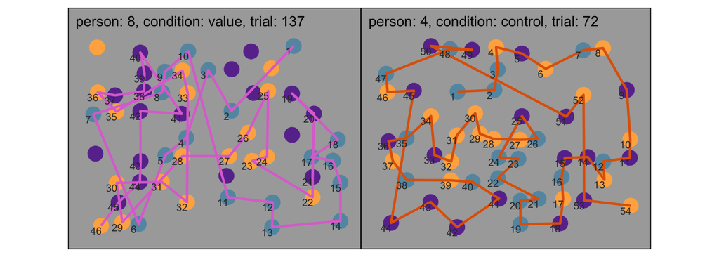

Figure 9: One trial per condition, simulated from the fitted model.

```r
plot_trial(p2, d$stim)
```

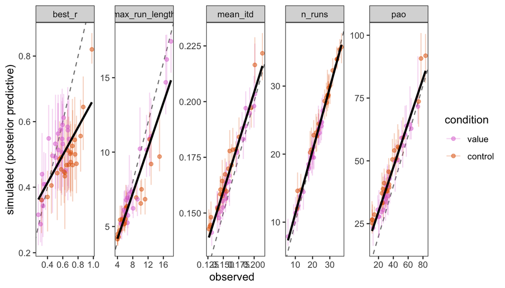

Figure 10: Trial statistics for the data (x) and simulated from the posterior (y). Points near the diagonal mean the model reproduces them.

```r
sim_stats <- compute_trial_stats(p2)
plot_trial_stats(trial_stats, sim_stats)
```

## 6 Model comparison: three item classes or two?

The fit above gives each target colour its own class, so the class transitions are a 3 x 3 matrix. The simpler alternative merges the two non-designated colours into one class (`tagu2022cog2items`: high-value against the rest), leaving a 2 x 2 matrix. The selections are the same, only the class labels differ, so the models’ leave-one-out predictions of each trial can be compared directly (the chunk checks that the two datasets are identical apart from the class). The 2-class fit has the same settings and was made by `../fit_models/fit_models.R`.

```r
# the same selections with the item classes merged: the two lower-value
# colours become one class (tagu2022cog2items). The selections are the
# same, so the two models' loo are comparable
d2 <- import_data("tagu2022cog2items")
stopifnot("the two versions should differ only in the item class" =
            identical(select(d$stim, -v), select(d2$stim, -v)),
          identical(select(d$found, -v), select(d2$found, -v)))

fit2 <- read_example_fit(d2, "tagu2022cog2items", "fourier124")
fits <- list(`3 classes` = fit, `2 classes` = fit2)
# loo for each fit, from the per-trial log-likelihoods the fits store
loos <- map(fits, \(f) f$loo())
```

`fomo_compare()` tabulates accuracy (against the nearest-neighbour rule) and loo. `elpd_diff` is the difference from the best model, `se_diff` its standard error, and `robust` whether the difference survives dropping the trials with unreliable (high Pareto k) loo estimates.

```r
cmp <- fomo_compare(fits, d, loos = loos)
format_compare(cmp, columns = c("model", "deterministic", "nn", "gain_nn", "elpd", "elpd_diff",
                                "se_diff", "pct_high_k", "stacking", "robust"))
```

| model | deterministic | nn | gain_nn | elpd | elpd_diff | se_diff | pct_high_k | stacking | robust |
| --- | --- | --- | --- | --- | --- | --- | --- | --- | --- |
| 3 classes | 0.624 | 0.521 | 0.103 | -29285 | 0 | 0 | 8.9 | 0.93 | TRUE |
| 2 classes | 0.593 | 0.521 | 0.071 | -30966 | -1680 | 118 | 5.8 | 0.07 | TRUE |

Three classes are far better: about 1,680 elpd ahead (SE 118), in both conditions (below). Merging the two lower-value colours hides how people move between them: in the 3-class fit, after selecting a colour-2 target the next is more likely colour 2 than colour 3 (log-odds 1.1 in the value condition, 1.5 in the control), and after colour 3 more likely colour 3 than colour 2 (1.4 in both). So people stick with the exact colour, not just with “not the high-value colour”, and they do so in the control condition too, where no colour is worth more: this is priming by colour, not value. About 9% of the 3-class model’s trials have unreliable loo estimates (high Pareto k), more than in the other datasets, but the difference survives without those trials (`robust`). Three classes also predict the next target better (accuracy 0.62 against 0.59).

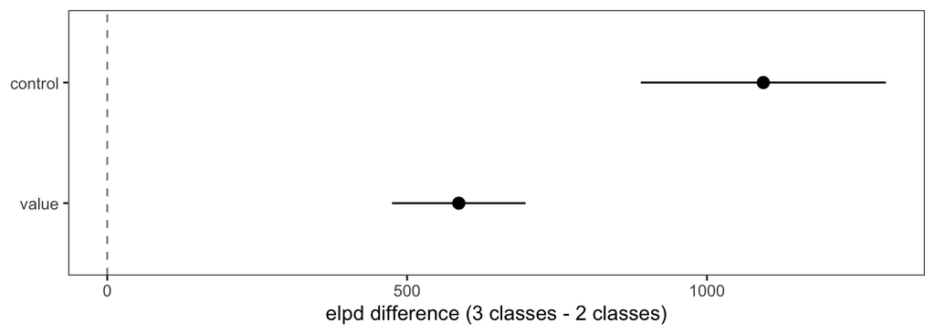

Figure 11: Difference in loo between the 3-class and 2-class models, summed over trials, by condition (point: sum; bars: 2 SE).

```r
# where the difference comes from: the loo difference summed over each
# condition's trials
plot_post_elpd_by_condition(loos, d$stim)
```

For reference, the 2-class model’s class transitions:

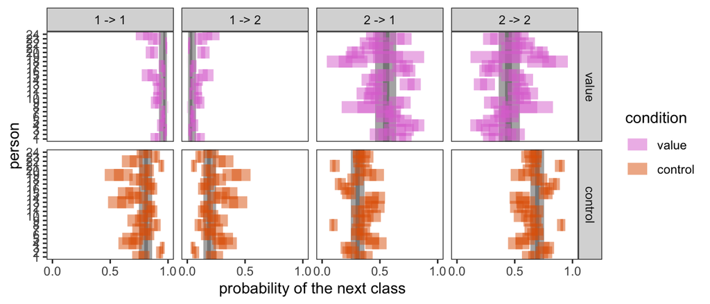

Figure 12: Per-person class-transition probabilities in the 2-class model.

```r
# the 2-class model's transitions, to compare with the 3-class ones above
plot_post_per_person_cat(extract_post(fit2, d2$found, d2$stim))
```